# Correlation Coefficient

| cor(father, son) |
| --- |
| 0.5007248 |

Sample correlation is a random variable. And is the best predictor for the population correlation,

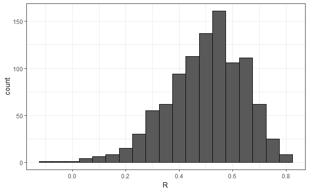

The correlation can also be applied with the Central Limit Theorem, therefore the correlation coefficient can be model by a normal variable with parameters:

$R \sim N(\rho,\sqrt(\frac{1-r^2}{N-2})$

Correlation is not always a good solution to infer trend between variables - One example is the Ascombe quartet, a conjunct of artificial data with different trends, in which all of them produce the same correlation coefficient

## Stratification

One way to predict son height based on the sample information and the father’s height is to do a stratification of the population and compute the conditional average:

```r
conditional_average
```

```
[1] 71.83571
```

This is larger than the average son.

stratification by boxplot can help to identify these stratas:

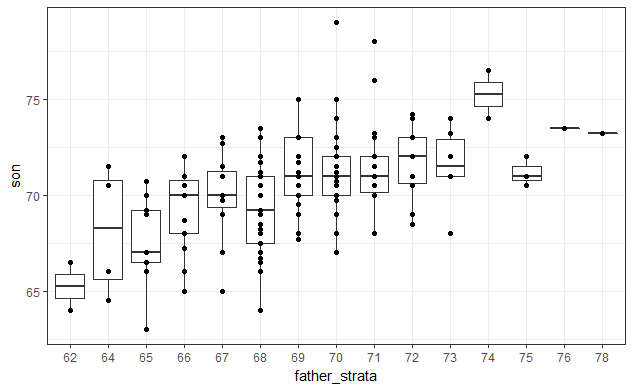

The means of each group seem to have a linear relationship:

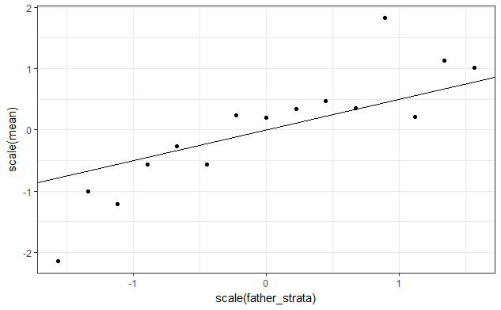

## Bivariate Normal Distribution

When a pair or variables (x,y) appear in a scatterplot with oval shape, it can be modelled as a bivariate normal distriution. Two variables highly correlated have a thin shape, or a circle if no correlation exists. both x and y must be approximately normally distributed.

```r
1-(1-0.5^2)*sd^2/sd^2
```

```
[1] 0.25
```